# Predicting the employee satisfaction levels at Salifort Motors

Providing data-driven suggestions for HR at Salifort Motors

Aravindh Venkatraman

30 July 2025

# Table of Contents

Statements  
Executive Summary

1. Introduction
2. Aim and Methodology of this Project
3. Exploratory Data Analysis - EDA
4. Machine Learning Model
5. Machine Learning Model - After Feature Engineering
6. Results & Discussion
7. Conclusion, Recommendations & Next Steps

# Statements

**Acknowledgement**  
I sincerely thank my parents and family for their unwavering support and encouragement, which enabled me to dedicate my time and effort to learning Machine Learning and Artificial Intelligence and applying them to environmental management challenges. I thank the Google Career Certification and Datacamp Certification courses for providing me the comprehensive resources and guidance to enhance my skills in Python, R Programming, and Machine Learning Concepts.

**Use of generative artificial intelligence**  
Generative Artificial Iintelligence (GenAI) tools were primarily used to assist in creating visualization, refining charts, and adjusting plotting parameters. In addition, GenAI was used for helping me write, debug code and improve workflow efficiency. All outputs generated by GenAI were carefully reviewed, modified and evaluated before implementation to ensure scientific accuracy, reliability, and alignment with the research objectives.

**Ethical Consideration and Transparency**  
This research was conducted with transparency, rigor, and ethical responsibility. All computational methods and analyses were independently validated, and any use of automated or AI-assisted tools was fully disclosed. The methodologies and code are provided to ensure reproducibility and facilitate future research.

**Data and Code Availability**  
Where applicable, datasets, code scripts, and analysis workflows used in this research are openly available upon request or in public repositories, supporting transparency and reproducibility in computational environmental management research.

# Executive Summary

**Problem Statement**  
Salifort Motors is a fictional French-based alternative energy vehicle manufacturer. The HR department at Salifort Motors wants to take some initiatives to improve employee satisfaction levels at the company. They refer to you as a data analytics professional and ask you to provide data-driven suggestions based on your understanding of the data. They have the following question: what’s likely to make the employee leave the company?

Because it is time-consuming and expensive to find, interview, and hire new employees, increasing employee retention will be beneficial to the company. If the data analyst can predict the factors influencing the employees likely to quit, it might be possible to identify main factors that contribute to their leaving.

**Project Aim and Focus**  
Goals in this project are to analyze the data collected by the HR department and to build a model that predicts whether or not an employee will leave the company.

**Raw data used**  
This project uses a dataset called `HR_capstone_dataset.csv`. It represents 10 columns of self-reported information from employees of a fictitious multinational vehicle manufacturing corporation.

**Results**  
Out of the models trained to predict the employee satisfaction, `Random Forest` model outperforms other models in predicting the employee satisfaction at Salifort Motors. The project assessment and analysis revealed that employee dissatisfaction at Salifort Motors is mainly driven by the company poor management, overwork and poor HR work policies.

**Key recommendations**  
Capping the number of projects per person, reviewing tenure-related dissatisfaction (especially at the four year mark), offering incentives for long working hours, HR department clarifying overtime work policies and implementing a balanced evaluation system. Suggestions to introduce structured feedback mechanisms prior to employee leaving to reduce data leakage.

# 1 Introduction

Salifort Motors is a fictional French-based alternative energy vehicle manufacturer. Its global workforce of over 100,000 employees research, design, construct, validate, and distribute electric, solar, algae, and hydrogen-based vehicles. Salifort’s end-to-end vertical integration model has made it a global leader at the intersection of alternative energy and automobiles.

The HR department at Salifort Motors wants to take some initiatives to improve employee satisfaction levels at the company. They collected data from employees, but now they don’t know what to do with it. They refer to the data analytics professional and ask them to provide data-driven suggestions based on your understanding of the data. They have the following question: what’s likely to make the employee leave the company?

Because it is time-consuming and expensive to find, interview, and hire new employees, increasing employee retention will be beneficial to the company. If the data analyst can predict the factors influencing the employees likely to quit, it might be possible to identify main factors that contribute to their leaving.

# 2 Aim and Methodology of this Project

For this project, the key stakeholders include the HR department and the senior leadership team, as they are directly involved in employee management and decision-making. The senior leadership team has tasked the data analyst with analyzing the dataset to come up with ideas for how to increase employee retention. To help with this, they would like you to build a machine learning model that predicts whether an employee will leave the company based on their department, number of projects, average monthly hours, and any other data points you deem helpful.

**Goals**  
The primary objective is to identify and predict the underlying drivers contributing to employee turnover, which can help in formulating effective retention strategies. Goals in this project are to analyze the data collected by the HR department and to build a model that predicts whether or not an employee will leave the company.

# 3 Exploratory Data Analysis - EDA

This project uses a dataset called HR_capstone_dataset.csv, which is downloaded from the Kaggle website [here](https://www.kaggle.com/datasets/mfaisalqureshi/hr-analytics-and-job-prediction?select=HR_comma_sep.csv). In the EDA, the dataset is analysed and prepared for building the machine learning models. Analysis such as,

- Loading the required packages and the data set
- Checking the descriptive statistics
- Check for missing, duplicate values and outliers
- Visualizing the relationship within or between the data variables

## 3.1 Load required libraries

First, loading the libraries and packages that are needed for predicting the employee satisfaction project. The selected libraries provide functions for handling data, building and performing machine learning tasks, and visualizing results.

```python
# Import packages
# Operational Packages
import numpy as np
import pandas as pd
import io
import pickle

# Visualization packages
import matplotlib.pyplot as plt
import seaborn as sns
from IPython.display import HTML
from IPython.display import display, Markdown
from tabulate import tabulate

# Modelling packages
from sklearn.preprocessing import StandardScaler, OneHotEncoder
from sklearn.model_selection import train_test_split, GridSearchCV
from sklearn.linear_model import LinearRegression, LogisticRegression
from sklearn.tree import DecisionTreeClassifier
from sklearn.ensemble import RandomForestClassifier

#XGBoost
from xgboost import XGBClassifier
from xgboost import XGBRegressor
from xgboost import plot_importance

# Modelling evaluation and metrics
from sklearn.metrics import accuracy_score, precision_score, recall_score,\
f1_score, confusion_matrix, ConfusionMatrixDisplay, classification_report
from sklearn.metrics import roc_auc_score, roc_curve
from sklearn.tree import plot_tree
from sklearn.tree import export_text
```

## 3.2 Data Loading and Pre-processing

### 3.2.1 Data Loading

To start the project, loading the dataset `HR_capstone_dataset.csv`, and analyse the basic of the dataset. The dataset represents 10 columns of self-reported information from employees of a fictitious multinational vehicle manufacturing corporation.

```python
# Load dataset into a dataframe
pd.set_option('display.max_columns', None)
pd.set_option('display.width', None)

# Load CSV
df0 = pd.read_csv(r"D:\Study\Machine Learning\Projects\Completed projects for GitHub\Predicting-the-employee-satisfaction-levels-at-Salifort-Motors\Data\HR_capstone_dataset.csv")

# Format first 5 rows
df0.head().style.set_table_attributes("class='table table-sm'")
```

|  | satisfaction_level | last_evaluation | number_project | average_montly_hours | time_spend_company | Work_accident | left | promotion_last_5years | Department | salary |
| --- | --- | --- | --- | --- | --- | --- | --- | --- | --- | --- |
| 0 | 0.380000 | 0.530000 | 2 | 157 | 3 | 0 | 1 | 0 | sales | low |
| 1 | 0.800000 | 0.860000 | 5 | 262 | 6 | 0 | 1 | 0 | sales | medium |
| 2 | 0.110000 | 0.880000 | 7 | 272 | 4 | 0 | 1 | 0 | sales | medium |
| 3 | 0.720000 | 0.870000 | 5 | 223 | 5 | 0 | 1 | 0 | sales | low |
| 4 | 0.370000 | 0.520000 | 2 | 159 | 3 | 0 | 1 | 0 | sales | low |

In this step, gaining a comprehensive understanding of the data set and preparing it for modelling is essential. This involves reviewing all variables to understand their data types, statistical distributions, and relevance to the target objective.

```python
# Print the descriptive statistics
df0.describe().style.set_table_attributes("class='table table-sm'")
```

|  | satisfaction_level | last_evaluation | number_project | average_montly_hours | time_spend_company | Work_accident | left | promotion_last_5years |
| --- | --- | --- | --- | --- | --- | --- | --- | --- |
| count | 14999.000000 | 14999.000000 | 14999.000000 | 14999.000000 | 14999.000000 | 14999.000000 | 14999.000000 | 14999.000000 |
| mean | 0.612834 | 0.716102 | 3.803054 | 201.050337 | 3.498233 | 0.144610 | 0.238083 | 0.021268 |
| std | 0.248631 | 0.171169 | 1.232592 | 49.943099 | 1.460136 | 0.351719 | 0.425924 | 0.144281 |
| min | 0.090000 | 0.360000 | 2.000000 | 96.000000 | 2.000000 | 0.000000 | 0.000000 | 0.000000 |
| 25% | 0.440000 | 0.560000 | 3.000000 | 156.000000 | 3.000000 | 0.000000 | 0.000000 | 0.000000 |
| 50% | 0.640000 | 0.720000 | 4.000000 | 200.000000 | 3.000000 | 0.000000 | 0.000000 | 0.000000 |
| 75% | 0.820000 | 0.870000 | 5.000000 | 245.000000 | 4.000000 | 0.000000 | 0.000000 | 0.000000 |
| max | 1.000000 | 1.000000 | 7.000000 | 310.000000 | 10.000000 | 1.000000 | 1.000000 | 1.000000 |

The `HR_capstone_dataset.csv` dataset contains 14999 row entries and 10 columns, out of which, 2 are float, 6 are integers and 2 are objects. Upon initial exploration of the data set, most of the variables in the survey data align with prediction variables but certain variables can be engineered for effective predictions. Ethical considerations at this point, is the consideration of the bias in the recorded data both during the analysis and while interpreting and presenting the results to ensure fairness and accuracy.  
Descriptive analysis of the dataset is shown here. Based on this,

- Most of the employees work on an average of ~3.8 projects and ~201 hours per month.
- Satisfaction levels range from 0.09 - 1 with a mean of ~0.61, while the last evaluation score is ~0.72.
- Most employees have not had accidents or been promoted in the last 5 years.

### 3.2.2 Data Exploration

In this step, the `HR_capstone_dataset.csv` dataset is then cleaned by addressing missing values, removing redundant or duplicate entries, and identifying any anomalies or inconsistencies. Outliers that could potentially distort model performance is also detected and evaluated for appropriate handling. These steps ensures that the dataset was accurate, consistent, and ready for further analysis, laying a solid foundation for building reliable predictive models.

**Rename columns**

As a data cleaning step, rename the columns as needed. Standardizing the column names so that they are all in `snake_case`, correcting any column names that are misspelled, and making sure column names more concise as needed.

```python
# Display all column names
list(df0.columns)
```

```
## ['satisfaction_level', 'last_evaluation', 'number_project', 'average_montly_hours', 'time_spend_company', 'Work_accident', 'left', 'promotion_last_5years', 'Department', 'salary']
```

```python
# Rename columns as needed
df = df0.copy()
df = df0.rename(columns={'satisfaction_level':'satisfaction',
                          'last_evaluation':'last_eval',
                          'number_project':'#_projects',
                          'average_montly_hours':'avg_mon_hrs',
                          'time_spend_company':'tenure',
                          'Work_accident':'work_accident',
                          'promotion_last_5years':'promotion_<5yrs',
                         'Department':'department'
                         })


# Display all column names after the update
list(df.columns)
```

```
## ['satisfaction', 'last_eval', '#_projects', 'avg_mon_hrs', 'tenure', 'work_accident', 'left', 'promotion_<5yrs', 'department', 'salary']
```

**Check missing values**

Checking for any missing values in the data.

```python
# Check for missing values
df.isnull().sum().reset_index().style.set_table_attributes("class='table table-sm'")
```

|  | index | 0 |
| --- | --- | --- |
| 0 | satisfaction | 0 |
| 1 | last_eval | 0 |
| 2 | #_projects | 0 |
| 3 | avg_mon_hrs | 0 |
| 4 | tenure | 0 |
| 5 | work_accident | 0 |
| 6 | left | 0 |
| 7 | promotion_<5yrs | 0 |
| 8 | department | 0 |
| 9 | salary | 0 |

There appears to be no missing values in this dataset.

**Check duplicates**

Checking for any duplicate entries in the data.

```python
# Check for duplicates
df.duplicated().sum()
```

```
## np.int64(3008)
```

```python
# Inspect some rows containing duplicates as needed
df[df.duplicated()].head().style.set_table_attributes("class='table table-sm'")
```

|  | satisfaction | last_eval | #_projects | avg_mon_hrs | tenure | work_accident | left | promotion_<5yrs | department | salary |
| --- | --- | --- | --- | --- | --- | --- | --- | --- | --- | --- |
| 396 | 0.460000 | 0.570000 | 2 | 139 | 3 | 0 | 1 | 0 | sales | low |
| 866 | 0.410000 | 0.460000 | 2 | 128 | 3 | 0 | 1 | 0 | accounting | low |
| 1317 | 0.370000 | 0.510000 | 2 | 127 | 3 | 0 | 1 | 0 | sales | medium |
| 1368 | 0.410000 | 0.520000 | 2 | 132 | 3 | 0 | 1 | 0 | RandD | low |
| 1461 | 0.420000 | 0.530000 | 2 | 142 | 3 | 0 | 1 | 0 | sales | low |

```python
# Drop duplicates and save resulting dataframe in a new variable as needed
df1 = df.drop_duplicates(keep='first')

# Display first few rows of new dataframe as needed
df1.head().style.set_table_attributes("class='table table-sm'")
```

|  | satisfaction | last_eval | #_projects | avg_mon_hrs | tenure | work_accident | left | promotion_<5yrs | department | salary |
| --- | --- | --- | --- | --- | --- | --- | --- | --- | --- | --- |
| 0 | 0.380000 | 0.530000 | 2 | 157 | 3 | 0 | 1 | 0 | sales | low |
| 1 | 0.800000 | 0.860000 | 5 | 262 | 6 | 0 | 1 | 0 | sales | medium |
| 2 | 0.110000 | 0.880000 | 7 | 272 | 4 | 0 | 1 | 0 | sales | medium |
| 3 | 0.720000 | 0.870000 | 5 | 223 | 5 | 0 | 1 | 0 | sales | low |
| 4 | 0.370000 | 0.520000 | 2 | 159 | 3 | 0 | 1 | 0 | sales | low |

Based on the duplicate data set, there are several continuous variables across all the 10 columns which is very highly likely that these observations are duplicates. Therefore dropping them will help in making accurate predictions.

**Check outliers**

Checking for outliers in the data. Certain types of models are more sensitive to outliers than others. Considering whether to remove outliers, is based on the type of models that will be used in the project.

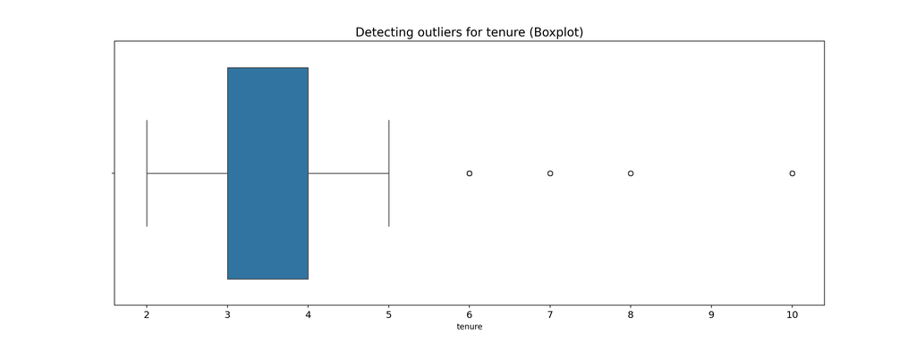

```python
# Create a boxplot to visualize distribution of `tenure` and detect any outliers
plt.figure(figsize=(16,6))
plt.title('Detecting outliers for tenure (Boxplot)', fontsize=15)
plt.xticks(fontsize=12);
plt.yticks(fontsize=12);
sns.boxplot(x=df1['tenure'])
plt.show()
```

The box plot shows that there are outliers in the `tenure` column. So, checking how many rows contain outliers in the `tenure` column.

```python
# Determine the number of rows containing outliers
# 25th Percentile for tenure
percentile25 = df1['tenure'].quantile(0.25)

# 75th Percentile for tenure
percentile75 = df1['tenure'].quantile(0.75)

# IQR - Inter Quartile Range
iqr = percentile75 - percentile25

# Limits of the tenure
upper_limit = percentile75 + 1.5 * iqr
lower_limit = percentile25 - 1.5 * iqr
print('Lower limit:', lower_limit)
```

```
## Lower limit: 1.5
```

```python
print('Upper limit:', upper_limit)
```

```
## Upper limit: 5.5
```

```python
# Identifying the outliers in 'tenure'
outliers = df1[(df1['tenure'] > upper_limit) | (df1['tenure'] < lower_limit)]

# print the rows containing the outliers
print(f'Number of rows containing outliers in tenure:', len(outliers))
```

```
## Number of rows containing outliers in tenure: 824
```

Outlier analysis in the tenure column indicates that employees with less than 1.5 years or more than 5.5 years of tenure show notable deviations, with 824 rows flagged as outliers. Most employees tend to leave within 5 years, possibly due to lack of advancement opportunities.

### 3.2.3 Data Visualization

Beginning by understanding how many employees left and what percentage of all employees this figure represents.

```python
# Get numbers of people who left vs. stayed
print(df['left'].value_counts())
```

```
## left
## 0    11428
## 1     3571
## Name: count, dtype: int64
```

```python
print()
```

```python
# Get percentages of people who left vs. stayed
df['left'].value_counts(normalize=True)
```

```
## left
## 0    0.761917
## 1    0.238083
## Name: proportion, dtype: float64
```

Examining variables that are interesting to the relevance of the project and create plots to visualize relationships between variables in the data.

- Correlation heat maps;
- Tenure vs satisfaction; tenure vs left distribution;
- #_project vs avg_mon_hrs;
- distribution of #_projects;
- satisfaction vs salary; satisfaction vs avg_mon_hrs;
- avg_mon_hrs vs last_eval; avg_mon_hrs vs promotion_<5yrs;
- distribution of left;

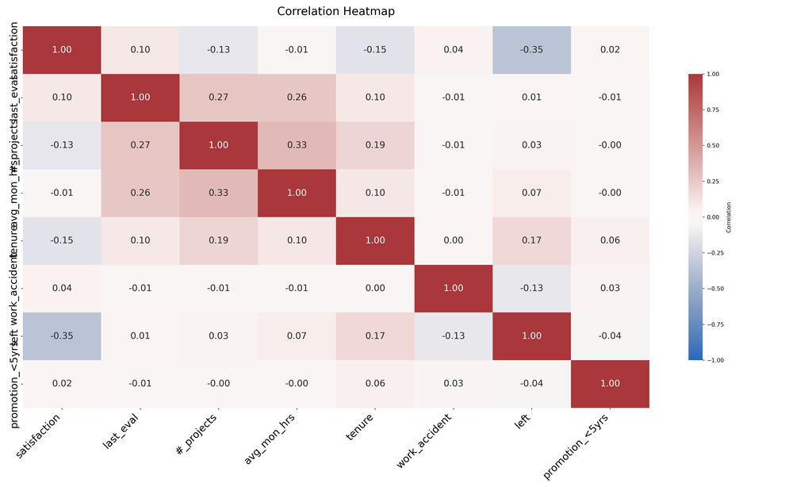

```python
# Select only numeric columns
numeric_df = df1.select_dtypes(include=['number'])

# Plot a correlation heatmap
plt.figure(figsize=(20, 12))
heatmap = sns.heatmap(
    numeric_df.corr(),
    vmin=-1,
    vmax=1,
    annot=True,
    fmt=".2f",  # optional: format annotation
    annot_kws={"size": 16},  # ← font size of annotation inside heatmap
    cmap=sns.color_palette("vlag", as_cmap=True),
    cbar_kws={"shrink": 0.75, "label": "Correlation"}  # optional: color bar label
)
heatmap.set_title('Correlation Heatmap', fontdict={'fontsize':20}, pad=20);

# Set x and y tick labels size
heatmap.set_xticklabels(heatmap.get_xticklabels(), rotation=45, ha='right', fontsize=18)
heatmap.set_yticklabels(heatmap.get_yticklabels(), fontsize=18)
plt.tight_layout()
plt.show()
```

**Correlation heatmap**

- **Positive Correlations:** Number of projects, average monthly hours, and evaluation scores all have the highest positive correlation with each other than the rest (>0.1)
- **Negative Correlation:** Whether or not an employee leaves is negatively correlates with their satisfaction level

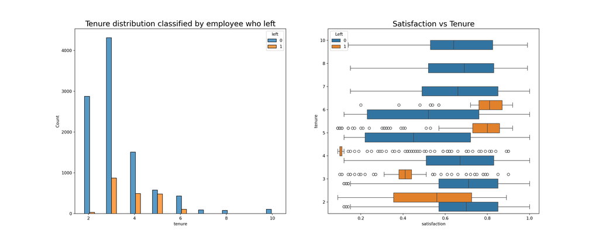

```python
# PLots to analyse Tenure vs satisfaction; tenure vs left distribution
# Set figure and axes
fig, ax = plt.subplots(1, 2, figsize = (20,8))

# Tenure vs left distribution
tenure_stay = df1[df1['left']==0]['tenure']
tenure_left = df1[df1['left']==1]['tenure']
sns.histplot(data=df1, x='tenure', hue='left', multiple='dodge', shrink=5, ax=ax[0])
ax[0].set_title('Tenure distribution classified by employee who left', fontsize=18)


# Tenure vs Satisfaction
sns.boxplot(data=df1, x='satisfaction', y='tenure', hue='left', orient="h", saturation=0.75, ax=ax[1])
ax[1].legend(loc='upper left', title='Left')
ax[1].invert_yaxis()
ax[1].set_title('Satisfaction vs Tenure', fontsize=18)

plt.show()
```

**Box Plot**

- Satisfaction level is similar to early and long tenure employees
- There is high dissatisfaction with short tenure employees who left and high satisfaction with employees who stayed with medium tenures
- There is very low dissatisfaction level in the medium (4 year) tenure employees who left

**Histogram Plot**

Histogram distribution shows that only few people stay more than 5 years which might be due to promotions to higher ranks in the company

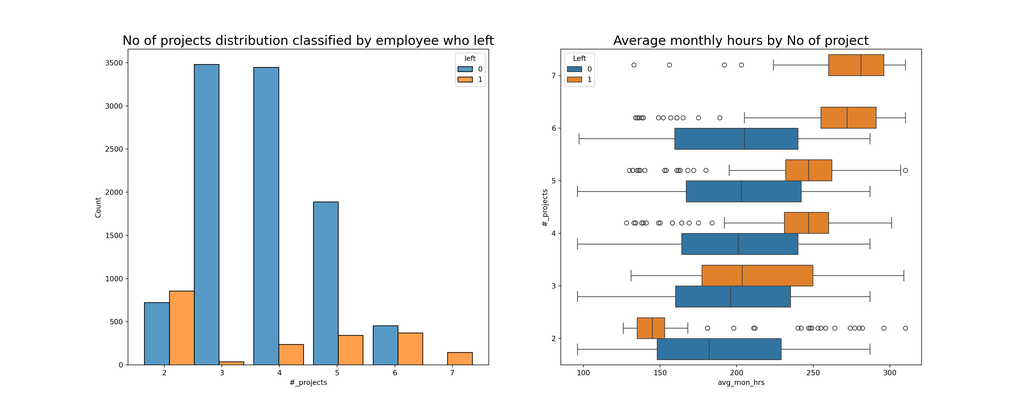

```python
# plot for #_project vs avg_mon_hrs; distribution of #_projects
fig, ax = plt.subplots(1, 2, figsize = (20,8))

# distribution of #_projects
projects_stay = df1[df1['left']==0]['#_projects']
projects_left = df1[df1['left']==1]['#_projects']
sns.histplot(data=df1, x='#_projects', hue='left', multiple='dodge', shrink=5, ax=ax[0])
ax[0].set_title('No of projects distribution classified by employee who left', fontsize=18)


# #_project vs avg_mon_hrs
sns.boxplot(data=df1, x='avg_mon_hrs', y='#_projects', hue='left', orient="h",saturation=0.75, ax=ax[1])
ax[1].legend(loc='upper left', title='Left')
ax[1].invert_yaxis()
ax[1].set_title('Average monthly hours by No of project', fontsize=18)
plt.show()
```

Based on the plots,

**Histogram**

- Average monthly working hours is in the range 160 - 200 hrs.
- Seems that employees who worked in 7 projects all left. Also employees with 6 projects worked more hours and but the ratio of who stayed and left is very similar. Here the mean hours of these groups between 250 - 300 hrs, indicating that they are overworked.
- Optimal number of projects for the employees are 3 and 4, the people who left are considerably less than the one who stayed.

**Box Plots**  
Employees who left the company,

- Those who worked longer hours and more projects, because of being overworked.
- Those who worked least hours and less projects, either they are fired or might have given notice to leave the company, so they were assigned fewer projects and worked lesser hours

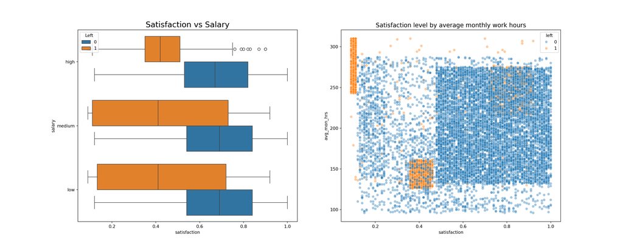

```python
# Plots for satisfaction vs salary; satisfaction vs last_eval;
fig, ax = plt.subplots(1, 2, figsize = (20,8))

# plot for satisfaction vs salary
sns.boxplot(data=df1, x='satisfaction', y='salary', hue='left',
            orient="h", saturation=0.75, ax=ax[0])
ax[0].invert_yaxis()
ax[0].legend(loc='upper left', title='Left')
ax[0].set_title('Satisfaction vs Salary', fontsize=18)

# Plot for satisfaction vs avg_mon_hrs
sns.scatterplot(data=df1, x='satisfaction', y='avg_mon_hrs', hue='left', alpha=0.4, ax=ax[1])
ax[1].set_title('Satisfaction level by average monthly work hours', fontsize=14)
```

Based on the plots,

**Box plot**

**Scatter plot**

Employees dissatisfaction level is very low who worked for long hours in the company and has a less than 0.5 satisfaction level aligns with employees who worked less hours which might be due to that they are fired or might have given notice to leave the company. This confirms with the previous box plots.

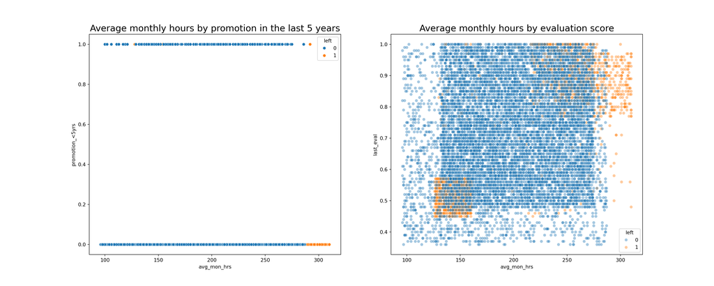

```python
# Plot for avg_mon_hrs vs last_eval; avg_mon_hrs vs promotion_<5yrs
fig, ax = plt.subplots(1, 2, figsize = (20,8))

# Plot for avg_mon_hrs vs promotion_<5yrs
sns.scatterplot(data=df1, x='avg_mon_hrs', y='promotion_<5yrs', hue='left', ax=ax[0])
ax[0].set_title('Average monthly hours by promotion in the last 5 years', fontsize=18)

# Plot for avg_mon_hrs vs last_eval
sns.scatterplot(data=df1, x='avg_mon_hrs', y='last_eval', hue='left', alpha=0.4, ax=ax[1])
ax[1].set_title('Average monthly hours by evaluation score', fontsize=18)
```

Based on the plot,

**avg_mon_hrs vs last_eval** Employeed who left,

- Overworked employees who worked well
- Employees who worked less and with low evaluation score
- Most of the employees work more than the average monthly work hours range

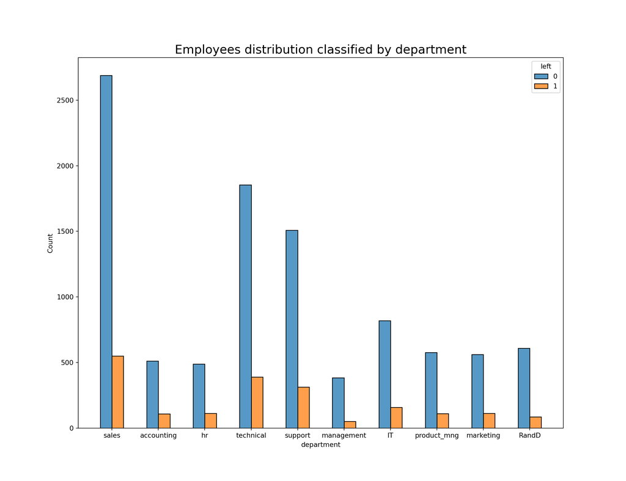

```python
# Plot for distribution of employee who left by department
plt.figure(figsize=(13,10))
sns.histplot(data=df1, x='department', hue='left', discrete=1,
             hue_order=[0, 1], multiple='dodge', shrink=.5)
plt.title('Employees distribution classified by department', fontsize=18)

plt.show()
```

Sales, Technical and Support department are the top three department where the employees left compared to the other departments

### 3.2.4 EDA Outcomes and Insights

Key drivers of employees who left are because,

- Long working hours
- High number of projects
- Not getting a promotion for their effort
- Low evaluation scores

Most of the employees are mostly burned out working long hours, more number of projects and not receiving any benefits such as promotion or higher salary. Dissatisfaction is prevalent among overworked staff, especially when rewards such as promotion or salary increments are absent. This findings highlight potential issues in poor company management and the company HR policies that might have to be investigated further and strategic action to improve employee satisfaction and retention.

# 4 Machine Learning Models

To assess the likelihood of the employee retention, logistic regression and tree based models - decision tree and random forest models were employed. The categorical variables are first encoded - `salary` was mapped ordinally from low to high, and `department` was mapped using dummy variables to retial information of all the categories. Outliers in the `tenure` was also removed to ensure better model stability and performance.

Logistic regression was selected for interpretability and ability to model linear relationships, while decision tree models were implemented to capture potential non-linear patters and interaction between variables. These two models offer complementary perspectives on the dataset, allowing for a more robust evaluation of predictive power and feature importance.

```python
# Encoding the categorical into numerical
# Copy the dataframe for the modelling
enc_df = df1.copy()

# Mapping the salary category with ordinal numbers according to hierarchy
salary_map = {'low':0, 'medium':1, 'high':2}

# Creating a new column for the salary map
enc_df['salary'] = enc_df['salary'].map(salary_map)

# Encoding the `department` with dummy variables
enc_df = pd.get_dummies(enc_df, drop_first=False)
enc_df.head().style.set_table_attributes("class='table table-sm'")
```

|  | satisfaction | last_eval | #_projects | avg_mon_hrs | tenure | work_accident | left | promotion_<5yrs | salary | department_IT | department_RandD | department_accounting | department_hr | department_management | department_marketing | department_product_mng | department_sales | department_support | department_technical |
| --- | --- | --- | --- | --- | --- | --- | --- | --- | --- | --- | --- | --- | --- | --- | --- | --- | --- | --- | --- |
| 0 | 0.380000 | 0.530000 | 2 | 157 | 3 | 0 | 1 | 0 | 0 | False | False | False | False | False | False | False | True | False | False |
| 1 | 0.800000 | 0.860000 | 5 | 262 | 6 | 0 | 1 | 0 | 1 | False | False | False | False | False | False | False | True | False | False |
| 2 | 0.110000 | 0.880000 | 7 | 272 | 4 | 0 | 1 | 0 | 1 | False | False | False | False | False | False | False | True | False | False |
| 3 | 0.720000 | 0.870000 | 5 | 223 | 5 | 0 | 1 | 0 | 0 | False | False | False | False | False | False | False | True | False | False |
| 4 | 0.370000 | 0.520000 | 2 | 159 | 3 | 0 | 1 | 0 | 0 | False | False | False | False | False | False | False | True | False | False |

```python
# Removing the outliers in the tenure and saving it in a new dataframe
df_lr = enc_df[(enc_df['tenure'] >= lower_limit) & (enc_df['tenure'] <= upper_limit)]

df_lr.head().reset_index(drop=True).style.set_table_attributes("class='table table-sm'")
```

|  | satisfaction | last_eval | #_projects | avg_mon_hrs | tenure | work_accident | left | promotion_<5yrs | salary | department_IT | department_RandD | department_accounting | department_hr | department_management | department_marketing | department_product_mng | department_sales | department_support | department_technical |
| --- | --- | --- | --- | --- | --- | --- | --- | --- | --- | --- | --- | --- | --- | --- | --- | --- | --- | --- | --- |
| 0 | 0.380000 | 0.530000 | 2 | 157 | 3 | 0 | 1 | 0 | 0 | False | False | False | False | False | False | False | True | False | False |
| 1 | 0.110000 | 0.880000 | 7 | 272 | 4 | 0 | 1 | 0 | 1 | False | False | False | False | False | False | False | True | False | False |
| 2 | 0.720000 | 0.870000 | 5 | 223 | 5 | 0 | 1 | 0 | 0 | False | False | False | False | False | False | False | True | False | False |
| 3 | 0.370000 | 0.520000 | 2 | 159 | 3 | 0 | 1 | 0 | 0 | False | False | False | False | False | False | False | True | False | False |
| 4 | 0.410000 | 0.500000 | 2 | 153 | 3 | 0 | 1 | 0 | 0 | False | False | False | False | False | False | False | True | False | False |

```python
list(df_lr.shape)
```

```
## [11167, 19]
```

## 4.1 Logistic Regression

Logistic regression is a supervised machine learning algorithm used for classification problems, especially when the target variable is binary. Unlike linear regression, which is used to predict continuous outcomes, logistic regression estimates the probability that a given input belongs to a particular category. It uses the logistic (sigmoid) function to map predicted values to a range between 0 and 1, making it ideal for predicting boolean outcomes.

Starting the logistic regression by setting the target and predictor variables. Then training the model with the training dataset and then using the test dataset to test the model.

```python
# Setting the 'y' variable
y = df_lr['left']

# Setting the 'x' variable with dropping the left column
X = df_lr.drop('left', axis=1)
```

```python
# Split the data into training (75%) and test (25%) dataset
X_train, X_test, y_train, y_test = train_test_split(X,y, test_size=0.25, stratify=y, random_state=0)

# Constructing the LogReg model
log_clf = LogisticRegression(random_state=0, max_iter=500)

# Fitting the model
log_clf.fit(X_train,y_train)
```

```
LogisticRegression(max_iter=500, random_state=0)
```

```python
# Use the model for the test dataset
y_pred = log_clf.predict(X_test)

# Constructing a confusion matrix
# Computing values in the matrix
log_cm = confusion_matrix(y_test, y_pred, labels=log_clf.classes_)

# Create display of confusion matrix
log_disp = ConfusionMatrixDisplay(confusion_matrix = log_cm,
                                  display_labels = log_clf.classes_)

# Plot confusion matrix
log_disp.plot(values_format='')
```

```
## <sklearn.metrics._plot.confusion_matrix.ConfusionMatrixDisplay object at 0x00000164711ACA00>
```

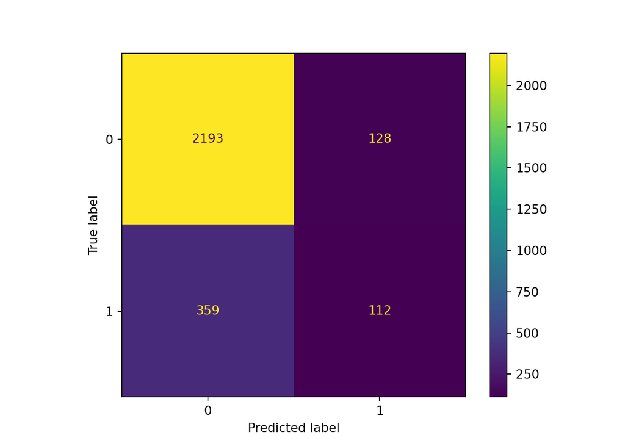

```python
# Display plot
plt.show()
```

Model accurately predicts,

- **True Positive -** No. of people who left = 112
- **True Negative -** No. of people who will not leave = 2193
- **False Positive -** No. of people who will not leave but predicted will leave = 128
- **False Negative -** No. of people who will leave but predicted will not leave = 359

**Checking the class imbalance**

```python
df_lr['left'].value_counts(normalize=True)
```

```
## left
## 0    0.831468
## 1    0.168532
## Name: proportion, dtype: float64
```

The data shows 83% - 17% split and shows imbalance. The class distribution is imbalanced, with only 17% of the data representing employees who left.

```python
# Create classification report for logistic regression model
row_names = ['Predicted would not leave', 'Predicted would leave']

# Generate report as dict
report_logr = classification_report(y_test, y_pred, target_names = row_names, output_dict=True)

# Choose averaging strategy
# Extract metrics
avg_type = 'weighted avg'
precision = report_logr[avg_type]['precision']
recall = report_logr[avg_type]['recall']
f1 = report_logr[avg_type]['f1-score']
accuracy = accuracy_score(y_test, y_pred)

# Needed for AUC
y_proba = log_clf.predict_proba(X_test)[:, 1]
auc = roc_auc_score(y_test, y_proba)


# Create the row
summary_row = {
    'Model': 'Logistic Regression',
    'Precision': round(precision, 6),
    'Recall': round(recall, 6),
    'F1': round(f1, 6),
    'Accuracy': round(accuracy, 6),
    'AUC': round(auc, 6)
}

# Convert to DataFrame
report_logr = pd.DataFrame([summary_row])
report_logr.style.set_table_attributes("class='table table-sm'")
```

|  | Model | Precision | Recall | F1 | Accuracy | AUC |
| --- | --- | --- | --- | --- | --- | --- |
| 0 | Logistic Regression | 0.793086 | 0.825573 | 0.801372 | 0.825573 | 0.892291 |

**Classification report shows,**

- Precision = 79%
- Recall = 83%
- F1 score = 80%
- Accuracy = 83%

The model shows very low scores in the objective which is the importance to predict employees who will leave.

## 4.2 Tree-based Model - Decision Tree & Random Forest

Tree-based models, such as Decision Trees and Random Forests, are powerful and intuitive methods used for both classification and regression tasks.

**A Decision Tree** splits the data into subsets based on the value of input features, creating a tree-like structure where each internal node represents a decision rule. It is easy to interpret but can be prone to overfitting.

To overcome this, **Random Forest**, an ensemble technique, builds multiple Decision Trees on different random subsets of the data and aggregates their predictions to improve accuracy and generalization. Random Forests reduce variance and handle high-dimensional data well, making them robust for complex modeling tasks.

Starting the tree based models by setting the target and predictor variables. Then training the model with the training dataset and then using the test dataset to test the model.

```python
# Using the enc_df dataframe
# Setting the y variable
y = enc_df['left']

# Setting the X variable
X = enc_df.drop('left',axis=1)

# Split the data into training (75%) and test (25%) dataset
X_train, X_test, y_train, y_test = train_test_split(X,y, test_size=0.25, stratify=y, random_state=0)
```

### 4.2.1 Decision Tree Model

```python
# Instantia the decision tree model
tree = DecisionTreeClassifier(random_state=0)

# Assign a dictionary of hyperparameters to search over
cv_params = {'max_depth':[2, 4, 6, None],
             'min_samples_leaf': [2, 6, 3],
             'min_samples_split': [2, 5,7]
             }

# Assign a dictionary of scoring metrics to capture
scoring = ['accuracy', 'precision', 'recall', 'f1', 'roc_auc']

# Instantiate GridSearch
dtree1 = GridSearchCV(tree, cv_params, scoring=scoring, cv=4, refit='roc_auc')
```

```python
# Fitting the model
dtree1.fit(X_train,y_train)
```

```
GridSearchCV(cv=4, estimator=DecisionTreeClassifier(random_state=0),
             param_grid={'max_depth': [2, 4, 6, None],
                         'min_samples_leaf': [2, 6, 3],
                         'min_samples_split': [2, 5, 7]},
             refit='roc_auc',
             scoring=['accuracy', 'precision', 'recall', 'f1', 'roc_auc'])
```

```python
# Check best parameters
print(dtree1.best_params_)
```

```
## {'max_depth': 4, 'min_samples_leaf': 6, 'min_samples_split': 2}
```

```python
# Check best AUC score on CV
print(dtree1.best_score_)
```

```
## 0.9698667651120891
```

```python
def make_results(model_name:str, model_object, metric:str):
    '''
    Arguments:
        model_name (string): what you want the model to be called in the output table
        model_object: a fit GridSearchCV object
        metric (string): precision, recall, f1, accuracy, or auc

    Returns a pandas df with the F1, recall, precision, accuracy, and auc scores
    for the model with the best mean 'metric' score across all validation folds.
    '''

    # Create dictionary that maps input metric to actual metric name in GridSearchCV
    metric_dict = {'auc': 'mean_test_roc_auc',
                   'precision': 'mean_test_precision',
                   'recall': 'mean_test_recall',
                   'f1': 'mean_test_f1',
                   'accuracy': 'mean_test_accuracy'
                  }

    # Get all the results from the CV and put them in a df
    cv_results = pd.DataFrame(model_object.cv_results_)

    # Isolate the row of the df with the max(metric) score
    best_estimator_results = cv_results.iloc[cv_results[metric_dict[metric]].idxmax(), :]

    # Extract Accuracy, precision, recall, and f1 score from that row
    auc = best_estimator_results.mean_test_roc_auc
    f1 = best_estimator_results.mean_test_f1
    recall = best_estimator_results.mean_test_recall
    precision = best_estimator_results.mean_test_precision
    accuracy = best_estimator_results.mean_test_accuracy

    # Create table of results
    table = pd.DataFrame()
    table = pd.DataFrame({'Model': [model_name],
                          'Precision': [precision],
                          'Recall': [recall],
                          'F1': [f1],
                          'Accuracy': [accuracy],
                          'AUC': [auc]
                        })

    return table
```

```python
# Get all CV scores
dtree1_cv_results = make_results('Decision Tree 1 CV', dtree1, 'auc')
dtree1_cv_results.reset_index(drop=True, inplace=True)
dtree1_cv_results.style.set_table_attributes("class='table table-sm'")
```

|  | Model | Precision | Recall | F1 | Accuracy | AUC |
| --- | --- | --- | --- | --- | --- | --- |
| 0 | Decision Tree 1 CV | 0.914490 | 0.916279 | 0.915345 | 0.971867 | 0.969867 |

The Decision Tree model demonstrated strong performance, achieving high scores across key metrics such as,

- Precision = 91.4%
- Recall = 91.6%
- F1-score = 91.5%
- Accuracy = 97.2%
- AUC = 0.97

These results indicate that the model fits the data well. However, the decision tree model is prone to overfitting. To address this concern and ensure better generalization, `Random Forest` Model was performed to compare the models.

### 4.2.2 Random Forest

```python
# Instantiate model
rf = RandomForestClassifier(random_state=0)

# Assign a dictionary of hyperparameters to search over
cv_params = {'max_depth': [3,5, None],
             'max_features': [1.0],
             'max_samples': [0.7, 1.0],
             'min_samples_leaf': [1,2,3],
             'min_samples_split': [2,3,4],
             'n_estimators': [300, 500],
             }

# Assign a dictionary of scoring metrics to capture
scoring = ['accuracy', 'precision', 'recall', 'f1', 'roc_auc']

# Instantiate GridSearch
rf1 = GridSearchCV(rf, cv_params, scoring=scoring, cv=4, refit='roc_auc', n_jobs=-1)
```

```python
# Fitting the model
rf1.fit(X_train, y_train)
```

```
GridSearchCV(cv=4, estimator=RandomForestClassifier(random_state=0), n_jobs=-1,
             param_grid={'max_depth': [3, 5, None], 'max_features': [1.0],
                         'max_samples': [0.7, 1.0],
                         'min_samples_leaf': [1, 2, 3],
                         'min_samples_split': [2, 3, 4],
                         'n_estimators': [300, 500]},
             refit='roc_auc',
             scoring=['accuracy', 'precision', 'recall', 'f1', 'roc_auc'])
```

```python
# Check best params
rf1.best_params_
```

```
## {'max_depth': 5, 'max_features': 1.0, 'max_samples': 0.7, 'min_samples_leaf': 1, 'min_samples_split': 4, 'n_estimators': 500}
```

```python
# Check best AUC score on CV
rf1.best_score_
```

```
## np.float64(0.9804250949807172)
```

```python
# Get all CV scores
rf1_cv_results = make_results('Random Forest 1 CV', rf1, 'auc')
results = pd.concat([rf1_cv_results,dtree1_cv_results], axis=0)
results.reset_index(drop=True, inplace=True)
results.style.set_table_attributes("class='table table-sm'")
```

|  | Model | Precision | Recall | F1 | Accuracy | AUC |
| --- | --- | --- | --- | --- | --- | --- |
| 0 | Random Forest 1 CV | 0.950023 | 0.915614 | 0.932467 | 0.977983 | 0.980425 |
| 1 | Decision Tree 1 CV | 0.914490 | 0.916279 | 0.915345 | 0.971867 | 0.969867 |

The `Random Forest` model also demonstrated strong performance on the training set, achieving high scores across key metrics such as,

- Precision = 95.0%
- Recall = 91.6%
- F1-score = 93.2%
- Accuracy = 97.8%
- AUC = 0.98

These metrics indicate the model’s strong ability to correctly classify both classes while maintaining high generalization performance.

Based on the model training results,

- `Random Forest` Model scores better than the Decision Tree, achieved higher precision, F1-score, accuracy, and AUC.
- `Random Forest` helps reduce overfitting, a known issue with standalone Decision Trees and improving predictive reliability.
- `Random Forest` Model performs well than the Decision Tree and the test set can be evaluated using the Random Forest.

```python
def get_scores(model_name:str, model, X_test_data, y_test_data):
    '''
    Generate a table of test scores.

    In:
        model_name (string):  How you want your model to be named in the output table
        model:                A fit GridSearchCV object
        X_test_data:          numpy array of X_test data
        y_test_data:          numpy array of y_test data

    Out: pandas df of precision, recall, f1, accuracy, and AUC scores for your model
    '''

    preds = model.best_estimator_.predict(X_test_data)

    auc = roc_auc_score(y_test_data, preds)
    accuracy = accuracy_score(y_test_data, preds)
    precision = precision_score(y_test_data, preds)
    recall = recall_score(y_test_data, preds)
    f1 = f1_score(y_test_data, preds)

    table = pd.DataFrame({'Model': [model_name],
                          'Precision': [precision],
                          'Recall': [recall],
                          'F1': [f1],
                          'Accuracy': [accuracy],
                          'AUC': [auc]
                         })

    return table
```

```python
# Get predictions on test data
rf1_test_scores = get_scores('Random Forest 1 Test', rf1, X_test, y_test)
rf1_test_scores.style.set_table_attributes("class='table table-sm'")
```

|  | Model | Precision | Recall | F1 | Accuracy | AUC |
| --- | --- | --- | --- | --- | --- | --- |
| 0 | Random Forest 1 Test | 0.964211 | 0.919679 | 0.941418 | 0.980987 | 0.956439 |

Round 1 Models included all the variables as features for the model prediction. For the Round 2 Models, Feature engineering will be used to customize the data for improving the model.

# 5 Machine Learning Model - After Feature Engineering

Relevant variables were selected and transformed to improve model performance, including encoding categorical features, handling missing values, and creating meaningful derived features to enhance predictive accuracy. What can be engineered in this dataset,

- Satisfaction level cannot be reported for all the employees. So, dropping it would be an option
- Average monthly hours might have data leakage, as it might be recorded after the employees gives notice to resign or company has given the notice to leave. So, maybe engineering this variable to a new variable as overworked might help improve the models prediction

```python
# Drop `satisfaction_level` and save resulting dataframe in new variable
df2 = enc_df.drop('satisfaction', axis=1)

# Display first few rows of new dataframe
df2.head().style.set_table_attributes("class='table table-sm'")
```

|  | last_eval | #_projects | avg_mon_hrs | tenure | work_accident | left | promotion_<5yrs | salary | department_IT | department_RandD | department_accounting | department_hr | department_management | department_marketing | department_product_mng | department_sales | department_support | department_technical |
| --- | --- | --- | --- | --- | --- | --- | --- | --- | --- | --- | --- | --- | --- | --- | --- | --- | --- | --- |
| 0 | 0.530000 | 2 | 157 | 3 | 0 | 1 | 0 | 0 | False | False | False | False | False | False | False | True | False | False |
| 1 | 0.860000 | 5 | 262 | 6 | 0 | 1 | 0 | 1 | False | False | False | False | False | False | False | True | False | False |
| 2 | 0.880000 | 7 | 272 | 4 | 0 | 1 | 0 | 1 | False | False | False | False | False | False | False | True | False | False |
| 3 | 0.870000 | 5 | 223 | 5 | 0 | 1 | 0 | 0 | False | False | False | False | False | False | False | True | False | False |
| 4 | 0.520000 | 2 | 159 | 3 | 0 | 1 | 0 | 0 | False | False | False | False | False | False | False | True | False | False |

```python
# Create `overworked` column. For now, it's identical to average monthly hours.
df2['overworked'] = df2['avg_mon_hrs']

# Inspect max and min average monthly hours values
print('Max hours:', df2['overworked'].max())
```

```
## Max hours: 310
```

```python
print('Min hours:', df2['overworked'].min())
```

```
## Min hours: 96
```

```python
# Define `overworked` as working > 175 hrs/week
df2['overworked'] = (df2['overworked'] > 175).astype(int)

# Display first few rows of new column
df2[['overworked']].head().style.set_table_attributes("class='table table-sm'")
```

|  | overworked |
| --- | --- |
| 0 | 0 |
| 1 | 1 |
| 2 | 1 |
| 3 | 1 |
| 4 | 0 |

Assuming the 40 hrs job/per week with two weeks vacation policy, Average working hours per month = 40 hours * 50 weeks / 12 months = 166.67 hours. **Overworked can be defined as working hours more than 175 hours per month on average.** Therefore, employees working more than 175 hours/month were classified as overworked (1), while others were labeled as not overworked (0).

To enrich the dataset with meaningful predictors, a new binary feature overworked was engineered based on average monthly working hours. This engineered feature adds interpretability to the model and allows it to capture the potential impact of excessive working hours on employee behavior or outcomes.

```python
# Drop the `average_monthly_hours` column
df2 = df2.drop('avg_mon_hrs', axis=1)

# Display first few rows of resulting dataframe
df2.head().style.set_table_attributes("class='table table-sm'")
```

|  | last_eval | #_projects | tenure | work_accident | left | promotion_<5yrs | salary | department_IT | department_RandD | department_accounting | department_hr | department_management | department_marketing | department_product_mng | department_sales | department_support | department_technical | overworked |
| --- | --- | --- | --- | --- | --- | --- | --- | --- | --- | --- | --- | --- | --- | --- | --- | --- | --- | --- |
| 0 | 0.530000 | 2 | 3 | 0 | 1 | 0 | 0 | False | False | False | False | False | False | False | True | False | False | 0 |
| 1 | 0.860000 | 5 | 6 | 0 | 1 | 0 | 1 | False | False | False | False | False | False | False | True | False | False | 1 |
| 2 | 0.880000 | 7 | 4 | 0 | 1 | 0 | 1 | False | False | False | False | False | False | False | True | False | False | 1 |
| 3 | 0.870000 | 5 | 5 | 0 | 1 | 0 | 0 | False | False | False | False | False | False | False | True | False | False | 1 |
| 4 | 0.520000 | 2 | 3 | 0 | 1 | 0 | 0 | False | False | False | False | False | False | False | True | False | False | 0 |

```python
# Isolate the outcome variable
y = df2['left']

# Select the features
X = df2.drop('left', axis=1)

# Create test data
X_train, X_test, y_train, y_test = train_test_split(X, y, test_size=0.25, stratify=y, random_state=0)
```

## 5.1 Decision Tree 2

```python
# Instantiate model
tree = DecisionTreeClassifier(random_state=0)

# Assign a dictionary of hyperparameters to search over
cv_params = {'max_depth':[4, 6, 8, None],
             'min_samples_leaf': [2, 5, 1],
             'min_samples_split': [2, 4, 6]
             }

# Assign a dictionary of scoring metrics to capture
scoring = ['accuracy', 'precision', 'recall', 'f1', 'roc_auc']

# Instantiate GridSearch
dtree2 = GridSearchCV(tree, cv_params, scoring=scoring, cv=4, refit='roc_auc')
```

```python
dtree2.fit(X_train, y_train)
```

```
GridSearchCV(cv=4, estimator=DecisionTreeClassifier(random_state=0),
             param_grid={'max_depth': [4, 6, 8, None],
                         'min_samples_leaf': [2, 5, 1],
                         'min_samples_split': [2, 4, 6]},
             refit='roc_auc',
             scoring=['accuracy', 'precision', 'recall', 'f1', 'roc_auc'])
```

```python
# Check best params
dtree2.best_params_
```

```
## {'max_depth': 6, 'min_samples_leaf': 2, 'min_samples_split': 6}
```

```python
# Check best AUC score on CV
dtree2.best_score_
```

```
## np.float64(0.9586752505340426)
```

```python
# Get all CV scores
dtree2_cv_results = make_results('Decision Tree 2 CV', dtree2, 'auc')
results = pd.concat([dtree1_cv_results,dtree2_cv_results,rf1_cv_results], axis=0)
results.reset_index(drop=True, inplace=True)
results.style.set_table_attributes("class='table table-sm'")
```

|  | Model | Precision | Recall | F1 | Accuracy | AUC |
| --- | --- | --- | --- | --- | --- | --- |
| 0 | Decision Tree 1 CV | 0.914490 | 0.916279 | 0.915345 | 0.971867 | 0.969867 |
| 1 | Decision Tree 2 CV | 0.856693 | 0.903553 | 0.878882 | 0.958523 | 0.958675 |
| 2 | Random Forest 1 CV | 0.950023 | 0.915614 | 0.932467 | 0.977983 | 0.980425 |

The `Decision tree 2` model balanced performance across all metrics, but slightly underperforms compared to both `Decision Tree 1 CV` and `Random Forest 1 CV`. such as,

- Precision = 85.7%
- Recall = 90.4%
- F1-score = 87.9%
- Accuracy = 95.9%
- AUC = 0.96

## 5.2 Random Forest 2

```python
# Instantiate model
rf = RandomForestClassifier(random_state=0)

# Assign a dictionary of hyperparameters to search over
cv_params = {'max_depth': [3,5, None],
             'max_features': [1.0],
             'max_samples': [0.7, 1.0],
             'min_samples_leaf': [1,2,3],
             'min_samples_split': [2,3,4],
             'n_estimators': [300, 500],
             }

# Assign a dictionary of scoring metrics to capture
scoring = ['accuracy', 'precision', 'recall', 'f1', 'roc_auc']

# Instantiate GridSearch
rf2 = GridSearchCV(rf, cv_params, scoring=scoring, cv=4, refit='roc_auc', n_jobs=-1)
```

```python
# Fitting the Model
rf2.fit(X_train, y_train)
```

```
GridSearchCV(cv=4, estimator=RandomForestClassifier(random_state=0), n_jobs=-1,
             param_grid={'max_depth': [3, 5, None], 'max_features': [1.0],
                         'max_samples': [0.7, 1.0],
                         'min_samples_leaf': [1, 2, 3],
                         'min_samples_split': [2, 3, 4],
                         'n_estimators': [300, 500]},
             refit='roc_auc',
             scoring=['accuracy', 'precision', 'recall', 'f1', 'roc_auc'])
```

```python
# Check best params
rf2.best_params_
```

```
## {'max_depth': 5, 'max_features': 1.0, 'max_samples': 0.7, 'min_samples_leaf': 2, 'min_samples_split': 2, 'n_estimators': 300}
```

```python
# Check best AUC score on CV
rf2.best_score_
```

```
## np.float64(0.9648100662833985)
```

```python
# Get all CV scores
rf2_cv_results = make_results('Random Forest 2 CV', rf2, 'auc')
results = pd.concat([dtree1_cv_results,dtree2_cv_results,rf1_cv_results,rf2_cv_results], axis=0)
results.reset_index(drop=True, inplace=True)
results.style.set_table_attributes("class='table table-sm'")
```

|  | Model | Precision | Recall | F1 | Accuracy | AUC |
| --- | --- | --- | --- | --- | --- | --- |
| 0 | Decision Tree 1 CV | 0.914490 | 0.916279 | 0.915345 | 0.971867 | 0.969867 |
| 1 | Decision Tree 2 CV | 0.856693 | 0.903553 | 0.878882 | 0.958523 | 0.958675 |
| 2 | Random Forest 1 CV | 0.950023 | 0.915614 | 0.932467 | 0.977983 | 0.980425 |
| 3 | Random Forest 2 CV | 0.866758 | 0.878754 | 0.872407 | 0.957411 | 0.964810 |

- Precision = 86.6%
- Recall = 87.9%
- F1-score = 87.2%
- Accuracy = 95.7%
- AUC = 0.964

Plotting a Confusion Matrix to visualize the model’s predictions on the test set

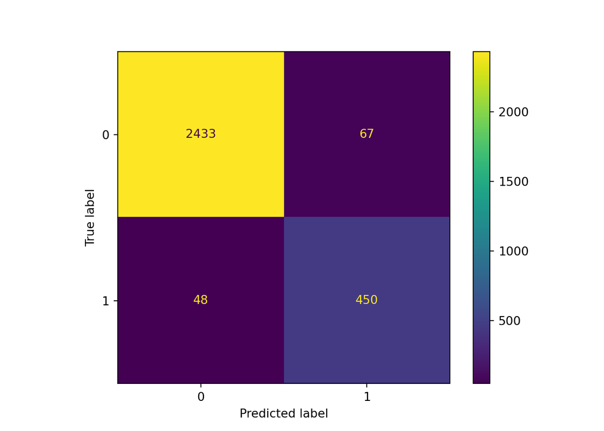

```python
# Generate array of values for confusion matrix
preds = rf2.best_estimator_.predict(X_test)
cm = confusion_matrix(y_test, preds, labels=rf2.classes_)

# Plot confusion matrix
disp = ConfusionMatrixDisplay(confusion_matrix=cm,
                             display_labels=rf2.classes_)
disp.plot(values_format='');
```

```python
# Get predictions on test data
rf2_test_scores = get_scores('Random Forest 2 Test', rf2, X_test, y_test)
test_results = pd.concat([rf1_test_scores, rf2_test_scores], axis=0)
test_results.reset_index(drop=True, inplace=True)
test_results.style.set_table_attributes("class='table table-sm'")
```

|  | Model | Precision | Recall | F1 | Accuracy | AUC |
| --- | --- | --- | --- | --- | --- | --- |
| 0 | Random Forest 1 Test | 0.964211 | 0.919679 | 0.941418 | 0.980987 | 0.956439 |
| 1 | Random Forest 2 Test | 0.870406 | 0.903614 | 0.886700 | 0.961641 | 0.938407 |

Based on the training results for the two rounds of Decision Tree and Random Forest Model,

- So `Random Forest 1 CV` model is the winning model and the test can now be used for prediction
- In general, `Random Forest` model performs well with ROC-AUC score as the deciding metric.

# 6 Results and Discussion

This section presents the results of various machine learning models applied to predict employee satisfaction at Salifort Motors. By evaluating different classifiers—ranging from logistic regression to ensemble methods—on cross-validation and test sets, we aim to identify the most accurate and reliable model for understanding the key drivers of employee satisfaction. The findings not only highlight model performance but also offer actionable insights into workforce dynamics and factors influencing satisfaction levels within the organization.

## 6.1 Logistic Regression

```python
report_logr.style.set_table_attributes("class='table table-sm'")
```

|  | Model | Precision | Recall | F1 | Accuracy | AUC |
| --- | --- | --- | --- | --- | --- | --- |
| 0 | Logistic Regression | 0.793086 | 0.825573 | 0.801372 | 0.825573 | 0.892291 |

The model shows very low scores in the objective which is the importance to predict employees who will leave. The data shows 83% - 17% split and shows imbalance. The class distribution is imbalanced, with only 17% of the data representing employees who left. This imbalance may contribute to the model’s bias toward predicting that employees will stay.

Based on the insights and limitations, it is worth exploring alternative classification models such as Decision Tree and Random Forest, which may handle non-linear relationships and imbalanced data more effectively, and potentially improve prediction of employee attrition.

## 6.2 Decision Tree

```python
# Get all CV scores
dt_results = pd.concat([dtree1_cv_results,dtree2_cv_results], axis=0)
dt_results.reset_index(drop=True, inplace=True)
dt_results.style.set_table_attributes("class='table table-sm'")
```

|  | Model | Precision | Recall | F1 | Accuracy | AUC |
| --- | --- | --- | --- | --- | --- | --- |
| 0 | Decision Tree 1 CV | 0.914490 | 0.916279 | 0.915345 | 0.971867 | 0.969867 |
| 1 | Decision Tree 2 CV | 0.856693 | 0.903553 | 0.878882 | 0.958523 | 0.958675 |

`Decision Tree 1 (CV)` outperformed `Decision Tree 2 (CV)` across all evaluation metrics. It achieved a higher precision, recall, and F1 score, indicating better balance between false positives and false negatives. Additionally, it showed superior accuracy and AUC, suggesting a more robust overall classification performance.

### 6.2.1 Feature importance

```python
# Feature important
dtree2_importances = pd.DataFrame(dtree2.best_estimator_.feature_importances_,
                                 columns=['gini_importance'],
                                 index=X.columns
                                )
dtree2_importances = dtree2_importances.sort_values(by='gini_importance', ascending=False)

# Only extract the features with importances > 0
dtree2_importances = dtree2_importances[dtree2_importances['gini_importance'] != 0]
dtree2_importances.style.set_table_attributes("class='table table-sm'")
```

|  | gini_importance |
| --- | --- |
| last_eval | 0.343958 |
| #_projects | 0.343385 |
| tenure | 0.215681 |
| overworked | 0.093498 |
| department_support | 0.001142 |
| salary | 0.000910 |
| department_sales | 0.000607 |
| department_technical | 0.000418 |
| work_accident | 0.000183 |
| department_IT | 0.000139 |
| department_marketing | 0.000078 |

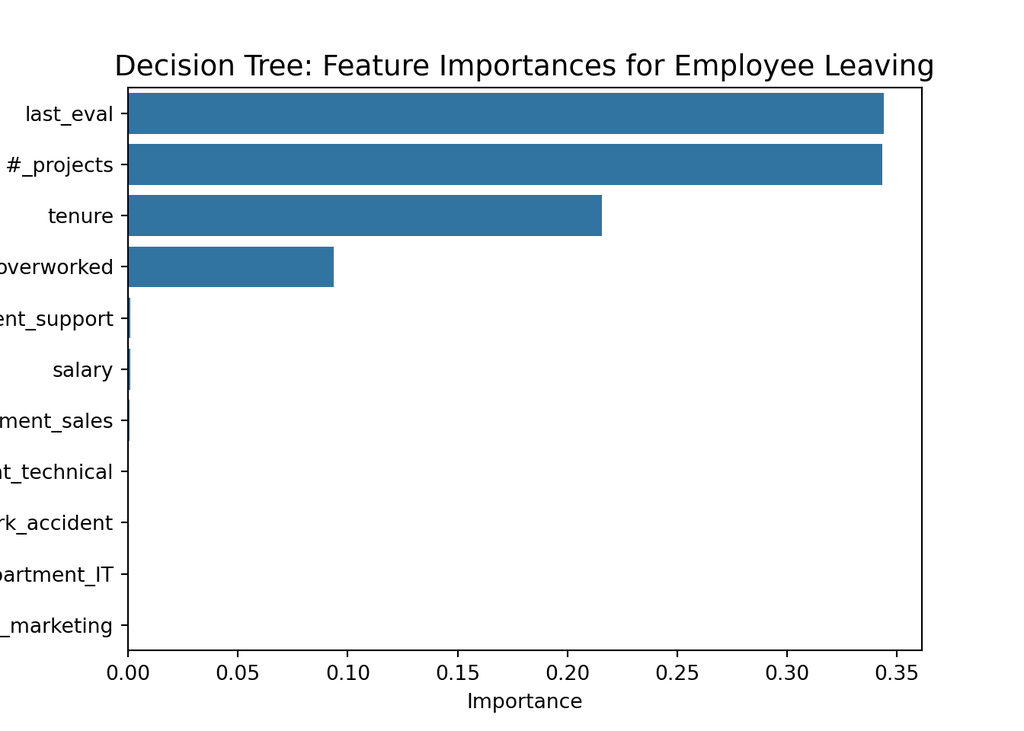

```python
sns.barplot(data=dtree2_importances, x="gini_importance", y=dtree2_importances.index, orient='h')
plt.title("Decision Tree: Feature Importances for Employee Leaving", fontsize=14)
plt.ylabel("Feature")
plt.xlabel("Importance")
plt.show()
```

Feature importance plot for the decision tree model shows that `last_evaluation`, `#_project`, `tenure`, and `overworked` have the importance from high to the least which helps in predicting the outcome variable ‘employee left’. In contrast, features like `department`, `salary`, and `work accident` contribute minimally to the prediction. This suggests that performance evaluation, workload, and time spent at the company are key factors influencing employee attrition.

### 6.2.2 Plotting the Decision Tree

```python
# Plot the tree
plt.figure(figsize=(85,50))
plot_tree(dtree2.best_estimator_, max_depth=6, fontsize=14, feature_names=X.columns,
          class_names={0:'stayed', 1:'left'}, filled=True);
plt.show()
```

[figure not shown]

```python
# Extract rules as plain text
tree_rules = export_text(dtree2.best_estimator_, feature_names=list(X.columns), max_depth=6)
print(tree_rules)
```

```
## |--- #_projects <= 2.50
## |   |--- last_eval <= 0.57
## |   |   |--- overworked <= 0.50
## |   |   |   |--- last_eval <= 0.44
## |   |   |   |   |--- class: 0
## |   |   |   |--- last_eval >  0.44
## |   |   |   |   |--- tenure <= 2.50
## |   |   |   |   |   |--- class: 0
## |   |   |   |   |--- tenure >  2.50
## |   |   |   |   |   |--- tenure <= 3.50
## |   |   |   |   |   |   |--- class: 1
## |   |   |   |   |   |--- tenure >  3.50
## |   |   |   |   |   |   |--- class: 0
## |   |   |--- overworked >  0.50
## |   |   |   |--- department_sales <= 0.50
## |   |   |   |   |--- department_IT <= 0.50
## |   |   |   |   |   |--- class: 0
## |   |   |   |   |--- department_IT >  0.50
## |   |   |   |   |   |--- tenure <= 3.00
## |   |   |   |   |   |   |--- class: 0
## |   |   |   |   |   |--- tenure >  3.00
## |   |   |   |   |   |   |--- class: 0
## |   |   |   |--- department_sales >  0.50
## |   |   |   |   |--- last_eval <= 0.47
## |   |   |   |   |   |--- class: 0
## |   |   |   |   |--- last_eval >  0.47
## |   |   |   |   |   |--- last_eval <= 0.48
## |   |   |   |   |   |   |--- class: 1
## |   |   |   |   |   |--- last_eval >  0.48
## |   |   |   |   |   |   |--- class: 0
## |   |--- last_eval >  0.57
## |   |   |--- last_eval <= 1.00
## |   |   |   |--- last_eval <= 0.75
## |   |   |   |   |--- department_technical <= 0.50
## |   |   |   |   |   |--- department_marketing <= 0.50
## |   |   |   |   |   |   |--- class: 0
## |   |   |   |   |   |--- department_marketing >  0.50
## |   |   |   |   |   |   |--- class: 0
## |   |   |   |   |--- department_technical >  0.50
## |   |   |   |   |   |--- last_eval <= 0.59
```

[output cut: 81 more lines]

```
## |   |   |   |   |   |--- #_projects <= 3.50
## |   |   |   |   |   |   |--- class: 0
## |   |   |   |   |   |--- #_projects >  3.50
## |   |   |   |   |   |   |--- class: 1
## |   |   |   |--- #_projects >  4.50
## |   |   |   |   |--- overworked <= 0.50
## |   |   |   |   |   |--- department_support <= 0.50
## |   |   |   |   |   |   |--- class: 0
## |   |   |   |   |   |--- department_support >  0.50
## |   |   |   |   |   |   |--- class: 0
## |   |   |   |   |--- overworked >  0.50
## |   |   |   |   |   |--- #_projects <= 5.50
## |   |   |   |   |   |   |--- class: 1
## |   |   |   |   |   |--- #_projects >  5.50
## |   |   |   |   |   |   |--- class: 1
```

1. **Number of Projects (#_projects)**  
   If ≤ 2.5 projects:
   - Most employees are satisfied, especially when:
     - Their last evaluation is low (≤ 0.44),
     - They are not overworked,
     - Their tenure is short (≤ 2.5 years).
   - A small group becomes unsatisfied if they have 3-year tenure and a slightly higher evaluation (> 0.44).

**Key Patterns**

- Employees with low workload, low evaluations, and short tenure are most likely to be satisfied.
- Overworked employees, especially those with 3-4 years tenure and mid-high evaluations, are at higher risk of dissatisfaction.
- Very high evaluation scores, low salary, and high project loads (>6) can sometimes flag discontent.

## 6.3 Random forest

```python
# Get all rf CV scores
rf_results = pd.concat([rf1_cv_results,rf2_cv_results], axis=0)
rf_results.reset_index(drop=True, inplace=True)
rf_results.style.set_table_attributes("class='table table-sm'")
```

|  | Model | Precision | Recall | F1 | Accuracy | AUC |
| --- | --- | --- | --- | --- | --- | --- |
| 0 | Random Forest 1 CV | 0.950023 | 0.915614 | 0.932467 | 0.977983 | 0.980425 |
| 1 | Random Forest 2 CV | 0.866758 | 0.878754 | 0.872407 | 0.957411 | 0.964810 |

```python
# Get all rf test scores
rf_test_results = pd.concat([rf1_test_scores, rf2_test_scores], axis=0)
rf_test_results.reset_index(drop=True, inplace=True)
rf_test_results.style.set_table_attributes("class='table table-sm'")
```

|  | Model | Precision | Recall | F1 | Accuracy | AUC |
| --- | --- | --- | --- | --- | --- | --- |
| 0 | Random Forest 1 Test | 0.964211 | 0.919679 | 0.941418 | 0.980987 | 0.956439 |
| 1 | Random Forest 2 Test | 0.870406 | 0.903614 | 0.886700 | 0.961641 | 0.938407 |

A perfect model would yield all true negatives and true positives, and no false negatives or false positives. The `Random Forest` models demonstrated strong performance on the test set. These results highlight the robustness and consistency of Random Forest classifiers in predicting employee outcomes.

In this case, the feature engineering did not improve model performance. Instead, it slightly degraded the classifier’s ability to distinguish between classes. This highlights the importance of validating each feature transformation step, as not all feature engineering enhances model learning — it can also obscure useful signals or increase dimensionality unnecessarily.

The `Random Forest 1` model consistently outperformed `Random Forest 2` across both cross-validation (CV) and test datasets. In cross-validation, `Random Forest 1` achieved a higher F1 score and accuracy compared to `Random Forest 2`. Similarly, in the test set, `Random Forest 1` yielded better performance with an F1 score and accuracy than `Random Forest 2`. The higher AUC values across both CV and test sets further confirm the superior classification performance of `Random Forest 1`.The `Random Forest` model’s performance will be similar when new unseen data is fitted, as the test data was used only for this model.

### 6.3.1 Feature importance

Now, plot the feature importance for the `Random Forest 2` model.

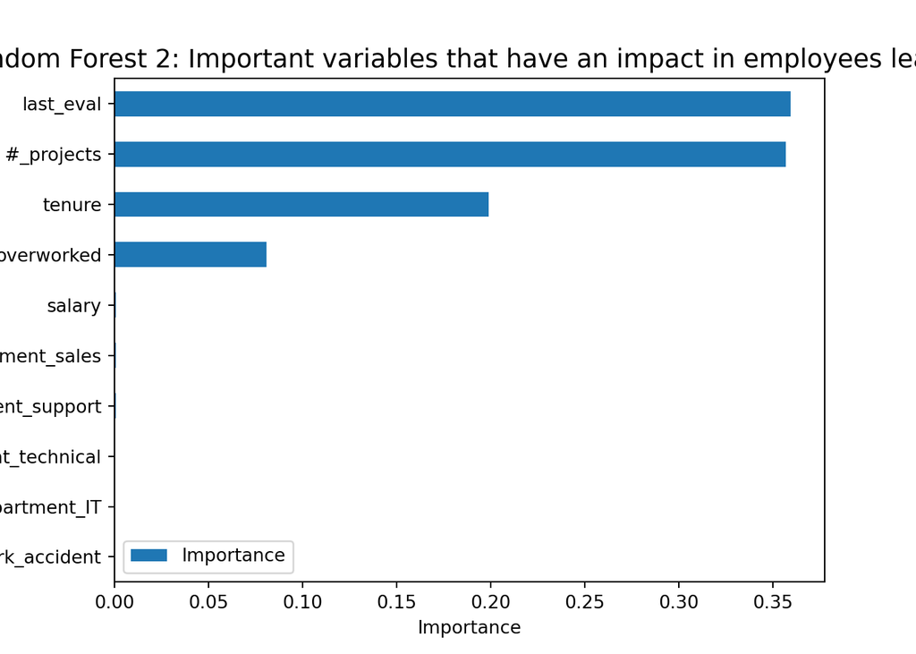

```python
# Get feature importances
feat_impt = rf2.best_estimator_.feature_importances_

# Get indices of top 10 features
ind = np.argpartition(rf2.best_estimator_.feature_importances_, -10)[-10:]

# Get column labels of top 10 features
feat = X.columns[ind]

# Filter `feat_impt` to consist of top 10 feature importance
feat_impt = feat_impt[ind]

y_df = pd.DataFrame({"Feature":feat,"Importance":feat_impt})
y_sort_df = y_df.sort_values("Importance")
fig = plt.figure()
ax = fig.add_subplot(111)

y_sort_df.plot(kind='barh', ax=ax, x="Feature", y="Importance")

ax.set_title("Random Forest 2: Important variables that have an impact in employees leaving", fontsize = 14)
ax.set_ylabel("Feature")
ax.set_xlabel("Importance")
plt.show()
```

Feature importance plot for the Random Forest is the same as the Decision Tree model - feature importance plot

## 6.4 Comparing and Evaluating the Models

```python
# Get all model scores
all_models = [report_logr, dtree1_cv_results, dtree2_cv_results, rf1_cv_results, rf2_cv_results, rf1_test_scores, rf2_test_scores]

model_results = pd.concat(all_models, axis = 0)
model_results.reset_index(drop = True, inplace = True)
model_results.style.set_table_attributes("class='table table-sm'")
```

|  | Model | Precision | Recall | F1 | Accuracy | AUC |
| --- | --- | --- | --- | --- | --- | --- |
| 0 | Logistic Regression | 0.793086 | 0.825573 | 0.801372 | 0.825573 | 0.892291 |
| 1 | Decision Tree 1 CV | 0.914490 | 0.916279 | 0.915345 | 0.971867 | 0.969867 |
| 2 | Decision Tree 2 CV | 0.856693 | 0.903553 | 0.878882 | 0.958523 | 0.958675 |
| 3 | Random Forest 1 CV | 0.950023 | 0.915614 | 0.932467 | 0.977983 | 0.980425 |
| 4 | Random Forest 2 CV | 0.866758 | 0.878754 | 0.872407 | 0.957411 | 0.964810 |
| 5 | Random Forest 1 Test | 0.964211 | 0.919679 | 0.941418 | 0.980987 | 0.956439 |
| 6 | Random Forest 2 Test | 0.870406 | 0.903614 | 0.886700 | 0.961641 | 0.938407 |

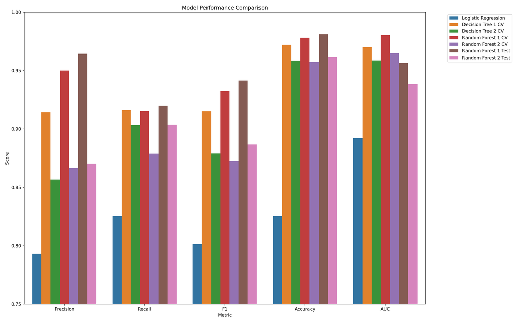

```python
# Model comparison visualization
model_results_melted = model_results.melt(id_vars = 'Model', var_name = 'Metric', value_name = 'Score')

# Plot
plt.figure(figsize=(16, 10))
sns.barplot(data = model_results_melted, x = 'Metric', y = 'Score', hue = 'Model')
plt.title('Model Performance Comparison')
plt.ylim(0.75, 1.0);
plt.legend(bbox_to_anchor = (1.05, 1), loc = 'upper left');
plt.tight_layout()
plt.show()
```

*Precision:* 96.42% *F1-score:* 94.14% *Accuracy:* 98.10%

This suggests that the model is not only accurate but also balanced in identifying both satisfied and unsatisfied employees with minimal false positives and false negatives.

**Insights**  
`Random Forest` is the most reliable model:

- It handles feature interactions and non-linearities well, making it a robust choice for complex, real-world data like employee satisfaction.

Its high performance on the test set also indicates good generalization to unseen employee data.

**`Decision Tree (CV)` and `Random Forest (CV)` also show strong performance:**  
With F1-scores over 91% and AUC scores over 96%, these models are effective in cross-validated settings, suggesting that even simpler tree-based models are insightful.

**`Logistic Regression` is less effective:**  
While it’s interpretable, its performance lags behind ensemble methods, likely due to its linear nature and limited capacity to model complex relationships.

**Model selection implications:**  
For business decision-making, `Random Forest` offers the best balance between precision and recall, helping HR departments accurately identify which employees are at risk of dissatisfaction. This allows for targeted interventions, retention strategies, and improved employee engagement.

# 7 Conclusion, Recommendations & Next Steps

From the initial assessment, EDA and Visualization, the employees are overworked due to the poor company management. This is also confirmed with the model and feature importance. The modeling efforts successfully demonstrate that employee satisfaction at Salifort Motors can be predicted with high accuracy using advanced machine learning methods, particularly `Random Forest`. These insights can empower HR leaders to proactively enhance workplace satisfaction and reduce turnover.

**Following recommendations could be presented to the stakeholders for retaining the employees:**

- Limiting or capping the number of projects that employees can work on.
- Investigating the dissatisfaction of the four year tenure employees
- Gratification or providing benefits for the employees working longer hours
- Informing the employees about the overtime work policies
- Evaluation scores must be defined and measured on a proportionate scale to be balanced for rewarding employees who work hard or put in more effort.

**Next Steps** Having a structured method for getting employees evaluation and satisfaction score before the employee leaves the company, as this might tend to data leakage. This might help in mitigating this issues and will help improve the model’s performance.